# 15 Time series analysis

> “Time is not a line but a dimension, like the dimensions of space. If you can bend space you can bend time also, and if you knew enough and could move faster than light you could travel backwards in time and exist in two places at once.”  
> — Margaret Atwood, in “Cat’s Eye”

Time series are sequences of measurements indexed by time: stock prices, temperature readings, heartbeat signals, sensor data. At first glance, they seem far from point clouds and topology. But there is a beautiful trick — *delay embeddings* — that converts a time series into a point cloud, opening the door to all the TDA tools we have developed.

## 15.1 From time series to point clouds

### 15.1.1 Takens’ embedding theorem

Given a time series $x_1, x_2, \ldots, x_N$, we can create a point cloud by looking at *windows* of consecutive values. Fix two parameters:

- $d$: the *embedding dimension* (how many consecutive values per window)
- $\tau$: the *delay* (spacing between consecutive values in a window)

The *delay embedding* maps the time series to a set of points $\{y_i\}$ in $\mathbb{R}^d$:

$$y_i = (x_i, x_{i+\tau}, x_{i+2\tau}, \ldots, x_{i+(d-1)\tau}).$$

Each $y_i$ is a snapshot of the time series behavior around time $i$.

**Note**

**Takens’ theorem** (1981) states that if the time series comes from a dynamical system with an attractor of dimension $m$, then for $d > 2m$ the delay embedding faithfully reconstructs the topology of the attractor. This is a remarkable result: from a single scalar measurement over time, we can recover the shape of the underlying dynamics!

### 15.1.2 Example: detecting periodicity

A purely periodic signal traces out a closed loop in delay-embedding space. This loop creates a 1-dimensional topological feature ($\beta_1 = 1$) that we can detect with persistent homology.

Let’s try it:

```julia
using Ripserer
using PersistenceDiagrams
using CairoMakie
using Random
using TDAplots
```

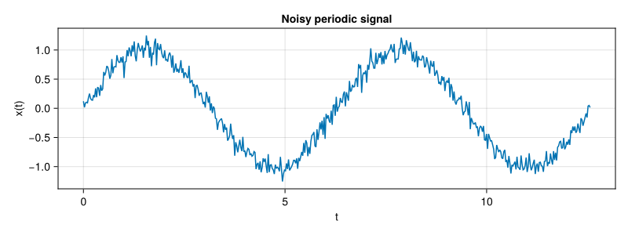

```julia
# A periodic signal: sin with some noise
N = 500
t = range(0, 4π, length = N)
signal = sin.(t) .+ 0.1 .* randn(MersenneTwister(42), N)

fig = Figure(size = (800, 300))
ax = Axis(fig[1, 1], title = "Noisy periodic signal", xlabel = "t", ylabel = "x(t)")
lines!(ax, t, signal)
fig
```

Now let’s apply delay embedding:

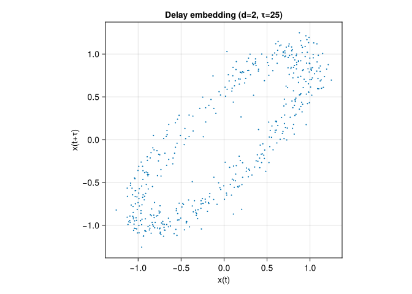

```julia
function delay_embedding(x, d, τ)
    N = length(x)
    M = N - (d - 1) * τ
    embedding = zeros(d, M)
    for i in 1:M
        for j in 1:d
            embedding[j, i] = x[i + (j - 1) * τ]
        end
    end
    return embedding
end

# Embed in 2D with delay τ=25
cloud = delay_embedding(signal, 2, 25)

fig = Figure()
ax = Axis(fig[1, 1], title = "Delay embedding (d=2, τ=25)",
    xlabel = "x(t)", ylabel = "x(t+τ)", aspect = DataAspect())
scatter!(ax, cloud[1, :], cloud[2, :], markersize = 3)
fig
```

The point cloud should look like a noisy circle — the topological signature of periodicity!

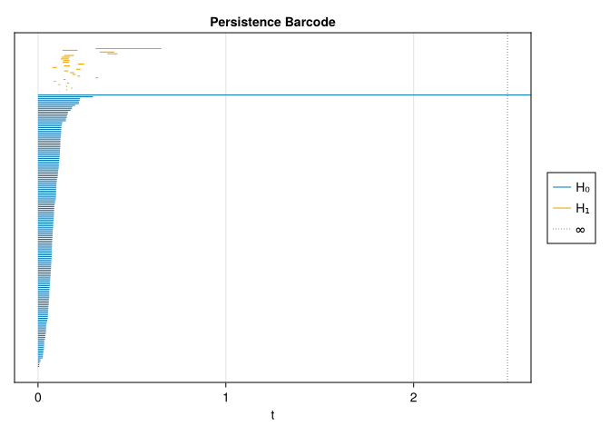

```julia
# Subsample for computational efficiency
idx = 1:3:size(cloud, 2)
pts = [Tuple(cloud[:, i]) for i in idx]

result = ripserer(Rips(pts; threshold = 2.5), dim_max = 1)
barcode_plot(result)
```

If the signal is truly periodic, we should see one prominent bar in $H_1$ — a loop that persists over a wide range of scales.

## 15.2 Detecting the lack of periodicity

What happens when the signal is *not* periodic? Let’s try with pure noise:

[figure not shown]

```julia
noise = randn(MersenneTwister(123), N)

cloud_noise = delay_embedding(noise, 2, 25)

fig = Figure(size = (800, 400))
ax1 = Axis(fig[1, 1], title = "White noise embedded (d=2)")
scatter!(ax1, cloud_noise[1, :], cloud_noise[2, :], markersize = 3)

# Compute PH on subsample
idx_noise = 1:3:size(cloud_noise, 2)
pts_noise = [Tuple(cloud_noise[:, i]) for i in idx_noise]
result_noise = ripserer(Rips(pts_noise; threshold = 3.0), dim_max = 1)

ax2 = Axis(fig[1, 2], title = "Barcode (white noise)")
fig
```

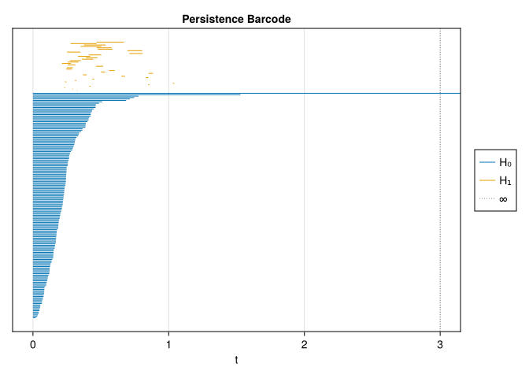

```julia
barcode_plot(result_noise)
```

## 15.3 Multiple periodicities

What if the signal has *two* independent periodicities? The delay embedding traces out a torus-like shape in higher dimensions:

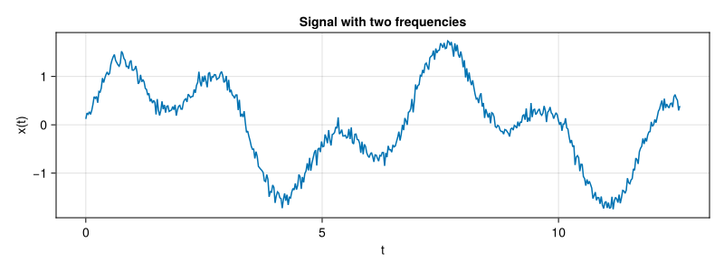

```julia
# Signal with two frequencies
signal2 = sin.(t) .+ 0.7 .* sin.(2.7 .* t) .+ 0.1 .* randn(MersenneTwister(7), N)

fig = Figure(size = (800, 300))
ax = Axis(fig[1, 1], title = "Signal with two frequencies", xlabel = "t", ylabel = "x(t)")
lines!(ax, t, signal2)
fig
```

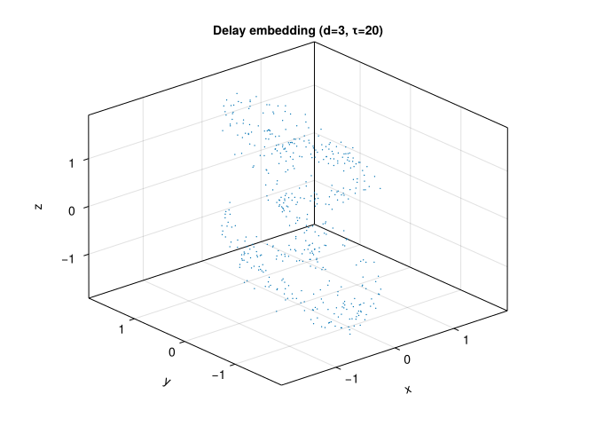

```julia
# Embed in 3D
cloud2 = delay_embedding(signal2, 3, 20)

fig = Figure()
ax = Axis3(fig[1, 1], title = "Delay embedding (d=3, τ=20)")
scatter!(ax, cloud2[1, :], cloud2[2, :], cloud2[3, :], markersize = 2)
fig
```

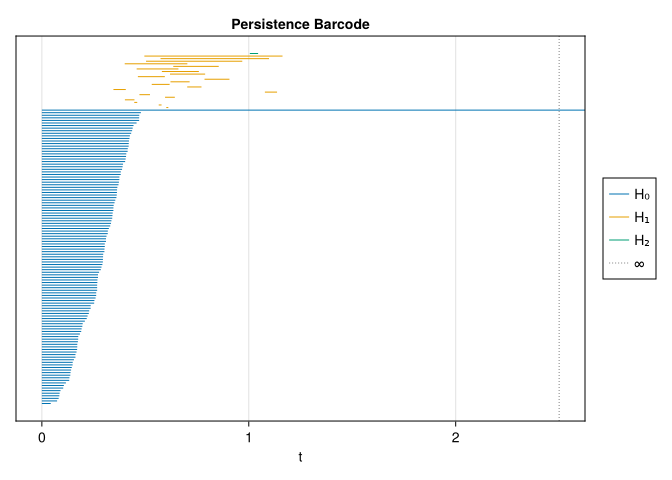

```julia
# PH of the embedding
idx2 = 1:4:size(cloud2, 2)
pts2 = [Tuple(cloud2[:, i]) for i in idx2]
result2 = ripserer(Rips(pts2; threshold = 2.5), dim_max = 2)
barcode_plot(result2)
```

## 15.4 Choosing embedding parameters

The choice of $d$ and $\tau$ matters:

- **Too small $d$**: the embedding doesn’t capture the full dynamics (Takens says we need $d > 2m$ where $m$ is the attractor dimension)
- **Too large $d$**: computational cost increases, and noise accumulates
- **Too small $\tau$**: consecutive points are nearly identical (the cloud concentrates near the diagonal)
- **Too large $\tau$**: consecutive points become almost independent (destroys temporal structure)

Practical heuristics:

- Use the *first minimum of the autocorrelation* or *mutual information* to choose $\tau$
- Use *false nearest neighbors* to choose $d$
- Start with $d = 2$ or $3$ for visualization, then increase

## 15.5 Summary

In this chapter we learned:

This provides a fundamentally different approach to time series analysis: instead of spectral methods (Fourier transforms) that assume linearity, TDA can detect nonlinear periodicities and complex dynamical structures.